# ch18

mht

December 2, 2014

# Ch 11: Signal detection theory

## 11.1: Signal detection theory

```
## Linked to JAGS 3.4.0
## Loaded modules: basemod,bugs
##
##
## module glm loaded
```

```
##    Graph Size: 43
##
```

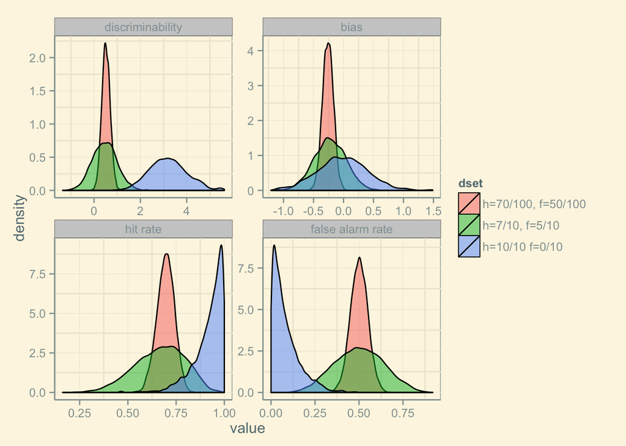

### Exercise 11.1.2

```
##    Graph Size: 43
##
```

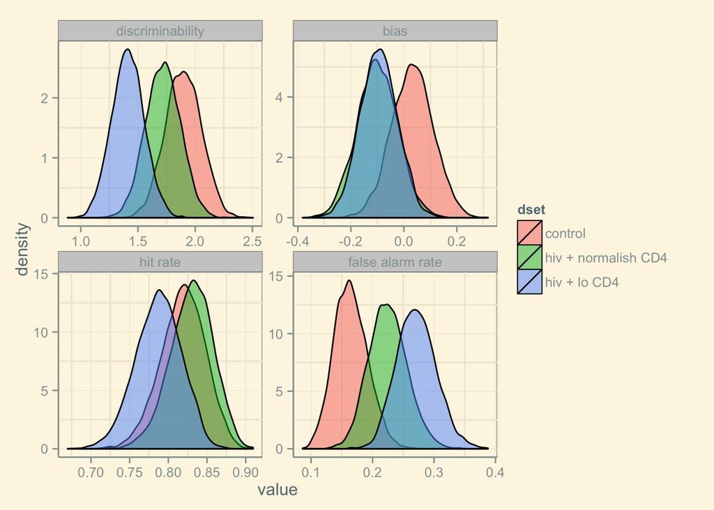

What conclusions do you draw from this analysis? What, if anything, can you infer about individual differences between the subjects in the same groups?

## 11.2 Hierarchical SDT

```
##    Graph Size: 455
##
##
##    Graph Size: 455
##
```

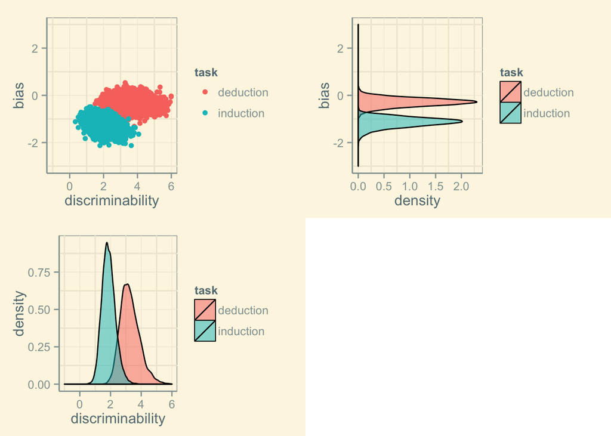

Of key interest for testing the Rips (2001) conjecture is how the group-level means for bias and (especially) discriminability differ between the induction and deduction conditions. What conclusion do you draw about the Rips (2001) conjecture base on the current analysis of the Heit and Rotello (2005) data?

Exercise 11.2.2 Heit and Rotello (2005) used standard significance testing meth- ods on their data to reject the null hypothesis that there was no difference between discriminability for induction and deduction conditions. Their analy- sis involved calculating the mean discriminabilities for each participant, using edge-corrections where perfect performance was observed. These sets of dis- criminabilities gave means of 0.93 for the deduction condition and 1.68 for the induction condition. By calculating via the t statistic, and so assuming associ- ated Gaussian sampling distributions, and observing that the p-value was less than 0.01, Heit and Rotello (2005) rejected the null hypothesis of equal means. According to Heit and Rotello (2005), this finding of different discriminabili- ties provided evidence against the criterion-shifting uni-dimensional account offered by SDT. Is this consistent with your conclusions from the Bayesian analysis?

### Exercise 11.2.3

Re-run the analysis without discarding burn-in samples. This can be done by setting nburnin to 0. The result should look something like Figure 11.6. Notice the strange set of samples leading from zero to the main part of the sampled distribution. Explain why these samples exist, and why they suggest burn-in is important in this analysis.

```
##    Graph Size: 455
##
##
##    Graph Size: 455
##
```

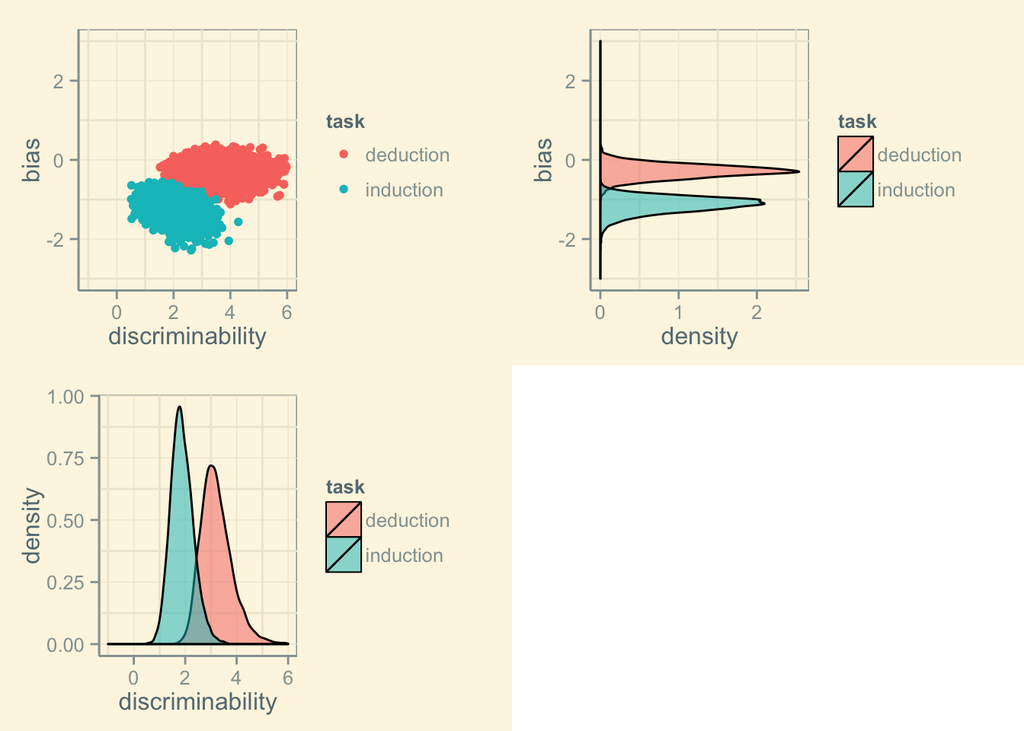

Maybe jags got better?

## 11.3 Parameter expansion

```
##    Graph Size: 622
##
##
##    Graph Size: 622
##
```

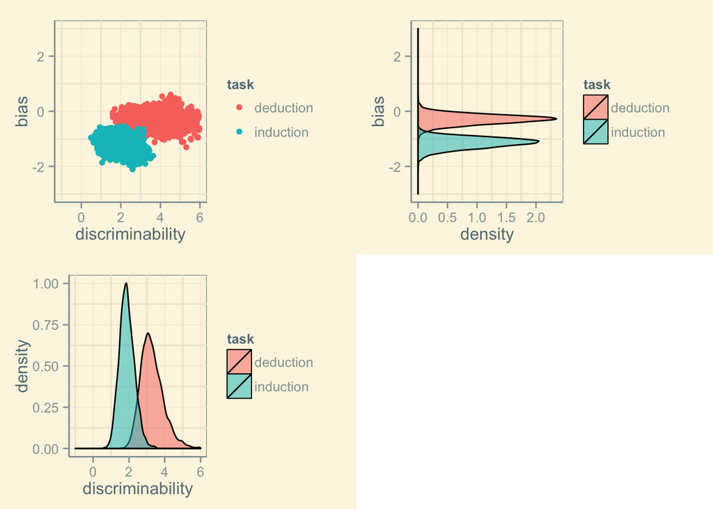